# Data Visualization & Anlayis of Bay-Wheels

## by Aditya Khosla

## Investigation Overview

I selected Ford GoBike dataset in order investigate the trend of bike hiring by different people.I live in the bay-area and tend to use the FordGo Bike for getting graceries from nearby Safeway and Target. I am active user of FordGoBike so the dataset intrigued to analyze and visualize the trends for the ford-go Bike Dataset. To see how people are using it and how long they travel and duration of their travel because I usually commute for shoter distances. I beleive becoming a subscriber $15/month is better than using Uber and lift

## Dataset Overview

The data set contains the files from 2017 to 2019 till July. The data set contains 16 variables such as startime,endtime,durationsec,member age and others. The data 3.8 million rides data. The users ranging from age 20-40 are frequent users of ForGoBike.There were some users that had age greater than 100 so we removed them. The ForGoBike is spread acroos BayArea. I will be focusing on San Jose as I am live in San Jose for the Presentation

# Distribution of Duration(hrs)

### In the distribution chart of the duration we can see that it is right skewed and most of the users in San Jose on average travel six miuntes to their destination

[figure not shown]

```python
bins=np.arange(0,np.log10(bike_sanjose['duration_hrs'].max()+0.01),0.01)
plt.figure(figsize=[10,10])
plt.hist(data=bike_sanjose,x='duration_hrs',bins=bins);
plt.xscale('log')
ticks=[0.01,0.03,0.1,0.3,1]
plt.xticks((ticks),ticks);
plt.yticks([2e3,4e3,6e3,8e3,1e4],['2k','4k','6k','8k','10k'])
plt.xlabel('Distance(kms)',fontsize=10);
plt.ylabel('Frequency',fontsize=10);
plt.suptitle('Distribution of Distance(km)',y=0.91,verticalalignment='baseline', fontsize = 15);
```

## Monthly Usage Trend of Bicycle Riders

### The plot below shows that in San Jose July-2019 had approximately 13000 bike rides made. This really good for the company. We can also see that countplot is multimodal as we can see drops in December and January; May be because of holiday season

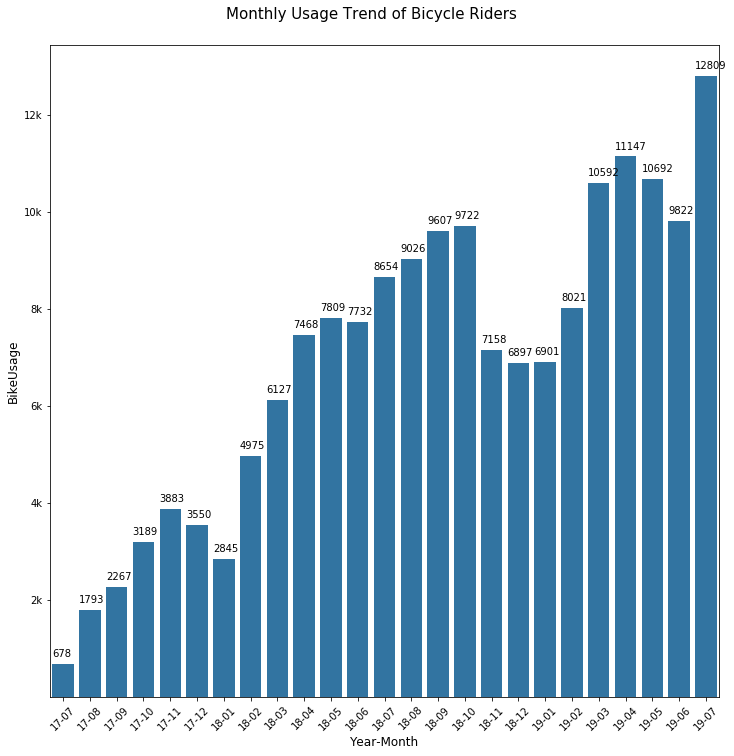

```python
##Creeating a plot
color=sb.color_palette()[0]
plt.figure(figsize=[12,12])
ax=sb.countplot(data=bike_sort,x='year_month',color=color);
plt.xlabel("Year-Month",fontsize=12);
plt.ylabel("BikeUsage",fontsize=12);
plt.suptitle("Monthly Usage Trend of Bicycle Riders ",y=0.91,verticalalignment='baseline', fontsize = 15);
plt.yticks([2e3,4e3,6e3,8e3,1e4,12e3],['2k','4k','6k','8k','10k','12k']);
plt.xticks(rotation=45)
for i in ax.patches:
    ax.text(i.get_x()+0,i.get_height()+150,i.get_height())
```

## Yearly,Monthly and WeekDay Trend of Bike Usage By Gender

```
Text(0.5,0.98,'Yearly,Monthly and WeekDay Trend of Bike Usage By Gender')
```

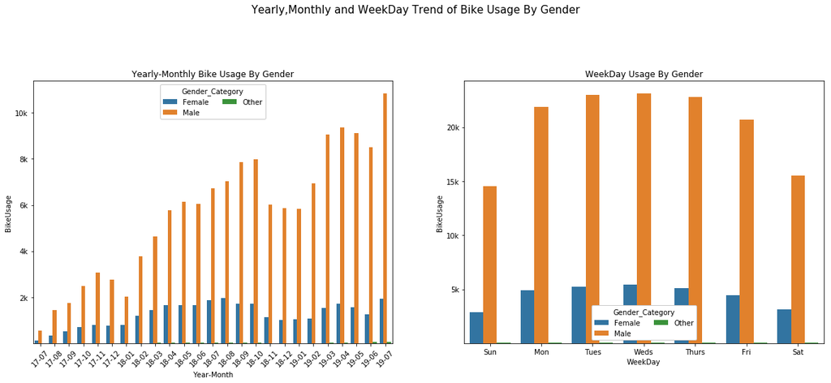

```python
plt.figure(figsize=[20,15])
plt.subplot(221)
order=['Sun','Mon','Tues','Weds','Thurs','Fri','Sat']
ax=sb.countplot(data=bike_sort,x='year_month',hue='member_gender');
plt.title("Yearly-Monthly Bike Usage By Gender")
plt.xlabel("Year-Month")
plt.ylabel("BikeUsage")
plt.xticks(rotation=45)
plt.yticks([2e3,4e3,6e3,8e3,1e4],['2k','4k','6k','8k','10k'])
ax.legend(loc=9,ncol=2,framealpha=1,title="Gender_Category")
plt.subplot(222)
ax=sb.countplot(data=bike_sort,x='day_of_week',hue='member_gender',order=order);
plt.title("WeekDay Usage By Gender")
plt.xlabel("WeekDay")
plt.ylabel("BikeUsage")
plt.yticks([5e3,1e4,15e3,2e4],['5k','10k','15k','20k'])
ax.legend(loc=8,ncol=2,framealpha=1,title="Gender_Category")
plt.suptitle("Yearly,Monthly and WeekDay Trend of Bike Usage By Gender",fontsize=15)
```

## Yearly,Monthly Usage Trend of the Bike Users from Age <70

### In the plot below we can see that 20-40 has drastically increased. It shows good pattern for the company. We can see that people in thier 30's to 50's should use the bicycle more. The company should focus on that age group to make it easier for the users of that age to use the bike in San Jose

```
Text(0.5,0.91,'Year-Month Bike Usage by Age Group')
```

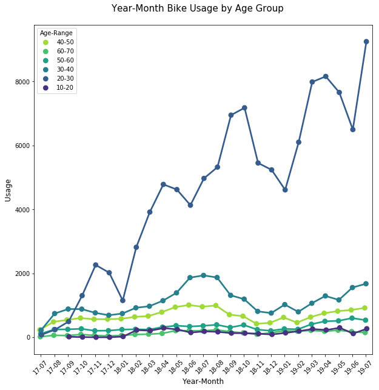

```python
plt.figure(figsize=[10,10])
g=sb.pointplot(data=group1,x="year_month",y="usage",hue="age_range",ci=None,dodge=True,palette='viridis_r');
plt.xticks(rotation=45)
ax=g.legend()
ax.set_title("Age-Range")
plt.xlabel("Year-Month",fontsize=12)
plt.ylabel("Usage",fontsize=12)
plt.suptitle("Year-Month Bike Usage by Age Group",y=0.91,verticalalignment='baseline', fontsize = 15)
```

## Hourly Bike Sharing Trend by Customers and Subsribers

### That's a good sign we can see that in San Jose all most of the Subscribers share their bikes for work. We can see that customers don't share their Bikes for work. Most of the Bike Usage for Customers and Subscribers is between 17 to 18 hrs

```
Text(0,0.5,'Usage')
```

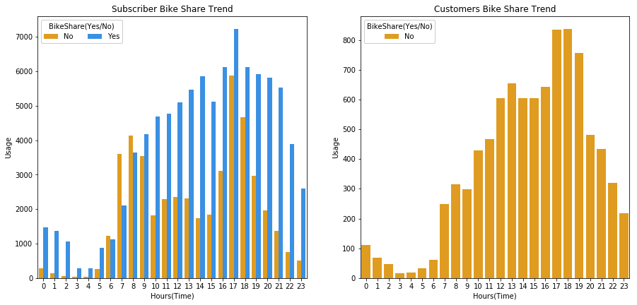

```python
##Plotting
plt.figure(figsize=[15,15])
plt.subplot(221)
ax=sb.barplot(data=group3,x="hour",y="usage",hue="bike_share_for_all_trip",palette=['orange','dodgerblue']);
plt.title("Subscriber Bike Share Trend")
ax.legend(loc=2,ncol=2,framealpha=1,title="BikeShare(Yes/No)")
plt.xlabel("Hours(Time)")
plt.ylabel("Usage")
plt.subplot(222)
ax=sb.barplot(data=group2,x="hour",y="usage",hue="bike_share_for_all_trip",palette=['orange','dodgerblue']);
plt.title("Customers Bike Share Trend")
ax.legend(loc=2,ncol=2,framealpha=1,title="BikeShare(Yes/No)")
plt.xlabel("Hours(Time)")
plt.ylabel("Usage")
```